# 深度学习基础

深度学习基础

6. 深度学习用于序列处理

WU Xiaokun [吴晓堃]

xkun.wu [at] gmail

2021/05/17

## 本章内容

处理文本数据。 理解循环神经网络。 循环神经网络的高级用法。 用卷积神经网络处理序列。

**重点**：使用预训练的词嵌入、使用LSTM 层和 GRU 层、使用一维卷积神经网络；

**难点**：分析不同循环神经网络的适用条件、提高循环神经网络的性能和泛化能力。

## 学习目标

- 理解并掌握处理文本数据的两种主要方法：one-hot编码、词嵌入；
- 理解并掌握简单循环神经网络（RNN）、LSTM 层和 GRU 层的工作原理；
- 理解并掌握提高循环神经网络的性能和泛化能力的三种高级技巧：循环 dropout降低过拟合、堆叠循环层提高网络的表示能力、双向循环层提高精度并缓解遗忘问题；
- 理解并掌握一维卷积神经网络的使用方法。

## 文本向量化

### 标记（token）

将文本分解而成的单元（单词、字符或 n-gram）。

```python
from keras.preprocessing.text import Tokenizer

samples = ['...', '...', ...]

tokenizer = Tokenizer(num_words=1000)
tokenizer.fit_on_texts(samples)

one_hot_encode = tokenizer.texts_to_matrix(
    samples, mode='binary')
```

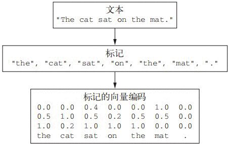

## 标记的向量编码

### 两种主要方法

- one-hot 编码：高维稀疏表示，即散列；硬编码得到；
- 标记嵌入：低维密集表示，从数据中学习得到。

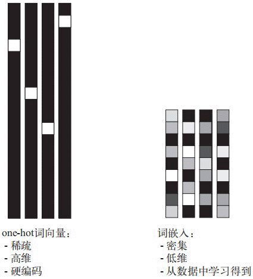

## 学习词嵌入

### 几何关系表示语义关系

- 距离：与语义关系远近正相关；
- 方向：同类别在相近方向上聚集。

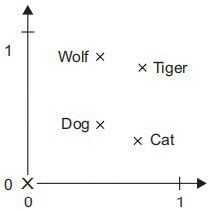

### 从数据中学习词嵌入

```python
from keras.layers import Embedding

model.add(Embedding(1000, 64, input_length=maxlen))
```

### 使用预训练的词嵌入

```python
model.layers[0].set_weights([embedding_matrix])

model.layers[0].trainable = False
```

## 循环网络（RNN）

前馈网络（feedforward network）的问题：没有记忆。

### 具有内部环的网络架构

- 循环结构：遍历所有序列元素；
- 存储状态：包含与已查看内容相关的信息。

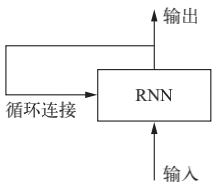

## RNN的简单表述：循环展开

### 时间步函数

`output~t~ = np.tanh(np.dot(W, input~t~) + np.dot(U, state~t~) + b)`

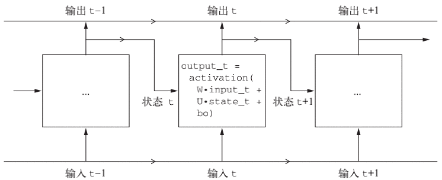

## 长短期记忆（LSTM）

### 长期记忆

- 解决遗忘问题：深层网络会出现梯度消失（vanishing gradient）现象；
- 长期携带信息：跨越多个时间步。

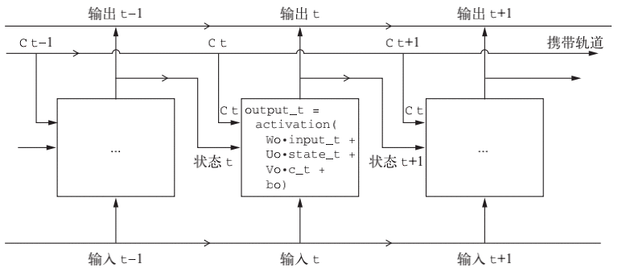

## LSTM：计算新的携带信息

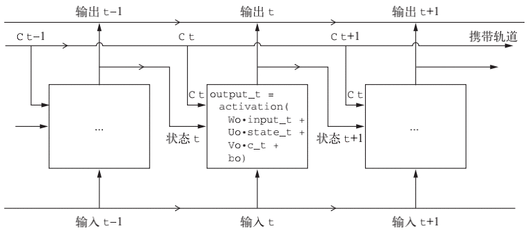

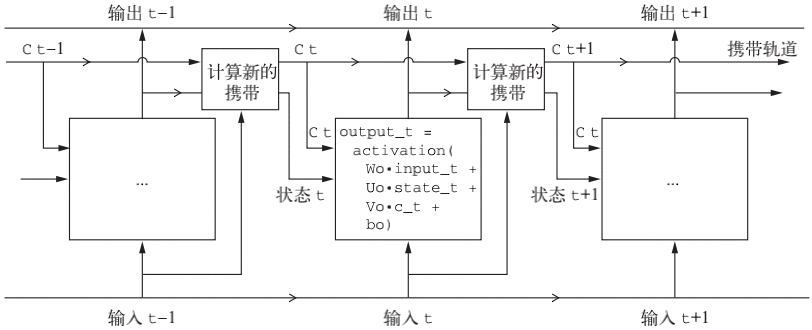

## 向量序列的二分类：LSTM示例

```python
from keras import models, layers

model = models.Sequential()
model.add(layers.LSTM(32, return_sequences=True, input_shape=(num_timesteps, num_features)))
model.add(layers.LSTM(32, return_sequences=True))
model.add(layers.LSTM(32))
model.add(layers.Dense(num_classes, activation='sigmoid'))

model.compile(optimizer='rmsprop', loss='binary_crossentropy')
```

## 一维卷积

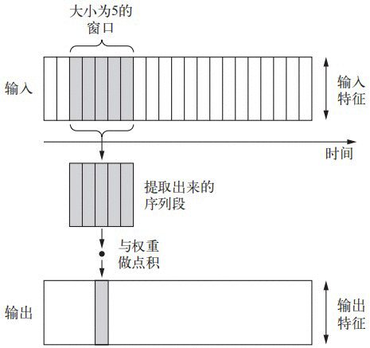